# Lab2

ShiVam Vashi

I didn’t have any groupmates for this project.

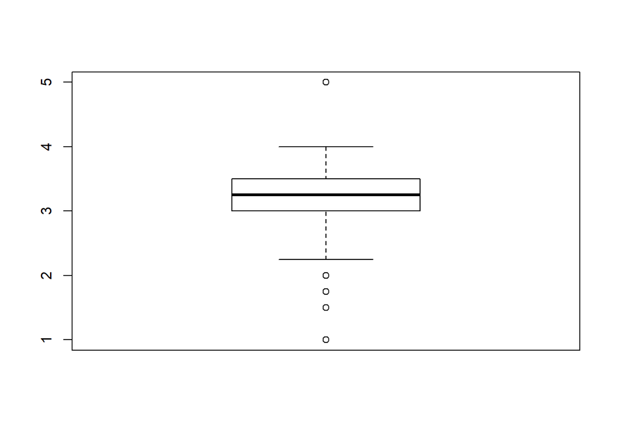

```r
choco <- read.csv("https://raw.githubusercontent.com/lbchu/ds202_labs/master/choco.csv")
boxplot(choco$Rating)
```

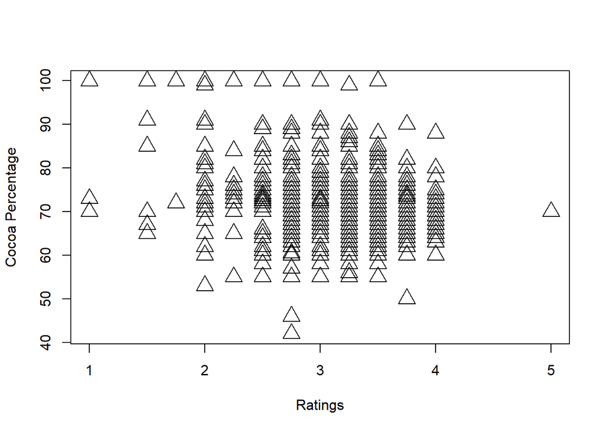

```r
plot(choco$Rating,choco$Cocoa.Pct, xlab = "Ratings", ylab = "Cocoa Percentage", pch = 2, cex=2)
```

Indiviual 1. How are ratings distributed? Don’t forget to mention outliers, if there are any.

Team

```r
recent_rating = choco[choco$Review.Date>2011,]
#Gets ratings of only reviews after 2011

unique(recent_rating$Company.Location) # NOTICE: how many countries are listed but how many levels are there?
```

```
##  [1] France            U.S.A.            Netherlands
##  [4] Brazil            Russia            Peru
##  [7] Canada            Italy             U.K.
## [10] Australia         Wales             Germany
## [13] Belgium           Spain             Puerto Rico
## [16] Venezuela         Colombia          Japan
## [19] New Zealand       Costa Rica        South Korea
## [22] Amsterdam         Scotland          Martinique
## [25] Guatemala         South Africa      St. Lucia
## [28] Portugal          Singapore         Denmark
## [31] Ecuador           Israel            Switzerland
## [34] India             Czech Republic    Domincan Republic
## [37] Finland           Philippines       Sweden
## [40] Poland            Vietnam           Austria
## [43] Madagascar        Honduras          U.A.E.
## [46] Lithuania         Nicaragua         Niacragua
## [49] Chile             Iceland           Mexico
## [52] Hungary           Suriname          Ireland
## 61 Levels: Amsterdam Argentina Australia Austria Belgium ... Wales
```

```r
#Gets only the unique locations from the reviews

recent_rating$Company.Location = droplevels(recent_rating$Company.Location)
#Deletes all repeated locations

head(recent_rating)
```

```
##    Company Specific.Bean.Origin  REF Review.Date Cocoa.Pct
## 1 A. Morin          Agua Grande 1876        2016        63
## 2 A. Morin                Kpime 1676        2015        70
## 3 A. Morin               Panama 1011        2013        70
## 4 A. Morin           Madagascar 1011        2013        70
## 5 A. Morin               Brazil 1011        2013        70
## 6 A. Morin             Equateur 1011        2013        70
##   Company.Location Rating Bean.Type Broad.Bean.Origin
## 1           France   3.75                    Sao Tome
## 2           France   2.75                        Togo
## 3           France   2.75                      Panama
## 4           France   3.00   Criollo        Madagascar
## 5           France   3.25                      Brazil
## 6           France   3.75                     Ecuador
```

```r
#Displays first couple values of recent rating

cross_table = table(recent_rating$Review.Date,recent_rating$Company.Location)
#Adds the recent rating and location tables together
cross_table
```

```
##
##        Amsterdam Australia Austria Belgium Brazil Canada Chile Colombia
##   2012         0         8      11       0      3      8     0        1
##   2013         0         4       0       4      5     18     0        0
##   2014         0         8       1       2      0     33     0        5
##   2015         4        12       0       4      3     18     2        1
##   2016         0        11       9       0      2     18     0        7
##   2017         2         2       1       0      1     13     0        0
##
##        Costa Rica Czech Republic Denmark Domincan Republic Ecuador Finland
##   2012          2              0       4                 0       2       0
##   2013          2              0       2                 5       0       0
##   2014          0              0       1                 0       7       1
##   2015          5              1       2                 0       3       0
##   2016          0              0       3                 0       1       1
```

[output cut: 49 more lines]

```r
#Displays table

which(cross_table[1,]!=0 & cross_table[2,]!=0 & cross_table[3,]!=0 & cross_table[4,]!=0 & cross_table[5,]!=0)
```

```
## Australia    Canada   Denmark    France   Germany      U.K.    U.S.A.
##         2         6        11        15        16        50        51
```

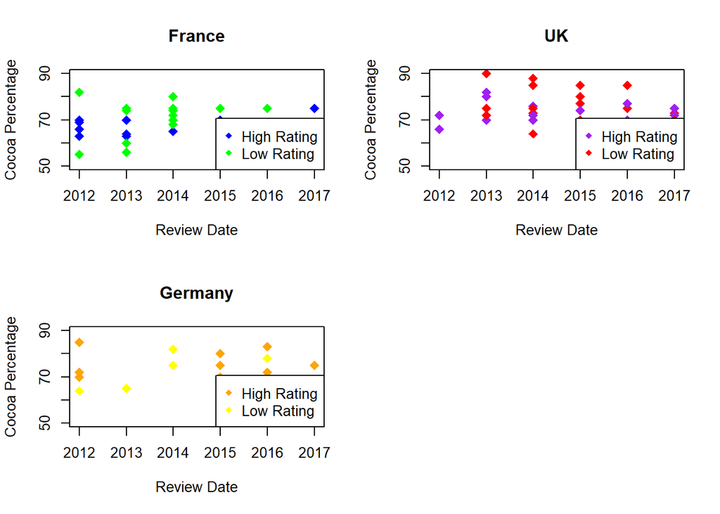

```r
#Shows all non zero entries

france_recent = subset(recent_rating,Company.Location =='France')
#Creates a subset of only French entries
uk_recent = subset(recent_rating,Company.Location =='U.K.')
#Creaes a subset of only U.K. entries
germany_recent = subset(recent_rating,Company.Location=='Germany')
#Creates a subset of only Germany

par(mfrow=c(2,2))
#Sets parameters for graphs
color1 = ifelse(france_recent$Rating >median(france_recent$Rating), 'blue', 'green')
#Sets colors for graph
plot(france_recent$Cocoa.Pct ~ france_recent$Review.Date,ylim=c(50,90),col=color1,pch=18,cex=1.5,xlab="Review Date", ylab= "Cocoa Percentage", main= "France")
#Plots France's data in a scatter plot
legend('bottomright',legend=c('High Rating', 'Low Rating'),col=c('blue','green'),pch=18)
#Adds legend


color2 = ifelse(uk_recent$Rating >median(uk_recent$Rating), 'purple', 'red')
#Sets colors for graph
plot(uk_recent$Cocoa.Pct ~ uk_recent$Review.Date,ylim=c(50,90),col=color2,pch=18,cex=1.5, xlab="Review Date", ylab= "Cocoa Percentage", main= "UK")
#Plots UK's data in a scatter plot
legend('bottomright',legend=c('High Rating', 'Low Rating'),col=c('purple','red'),pch=18)
#Adds legend

color3 = ifelse(germany_recent$Rating > median(germany_recent$Rating), 'orange', 'yellow')
#Sets colors for graph
plot(germany_recent$Cocoa.Pct ~ germany_recent$Review.Date,ylim=c(50,90),col=color3,pch=18,cex=1.5,xlab="Review Date", ylab= "Cocoa Percentage", main= "Germany")
#Plots Germany's data in a scatter plot
legend('bottomright',legend=c('High Rating', 'Low Rating'),col=c('orange','yellow'),pch=18)
#Adds legend
```

2 . Click Zoom on the Rstudio window (under Plots) to see the plot more clearly. How do you think the plot produced from the code above can be improved? Recommend at least one possible improvement. Making the graphs the width of the screen would help visibility.

3 . How does the **number** of ratings (not the actual value of the rating) depend on the year? Use graphics to answer this question.

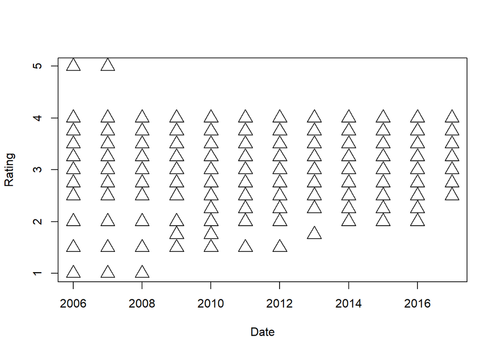

```r
plot(choco$Review.Date,choco$Rating, xlab = "Date", ylab = "Rating", pch = 2, cex=2)
```

4 . How do ratings compare across different company locations? Focus on the three locations with the most ratings. Hint: the function `sort()` might come in handy here.

```r
sort(choco$Company.Location)
```

[output not shown]

[output cut: 604 more lines]

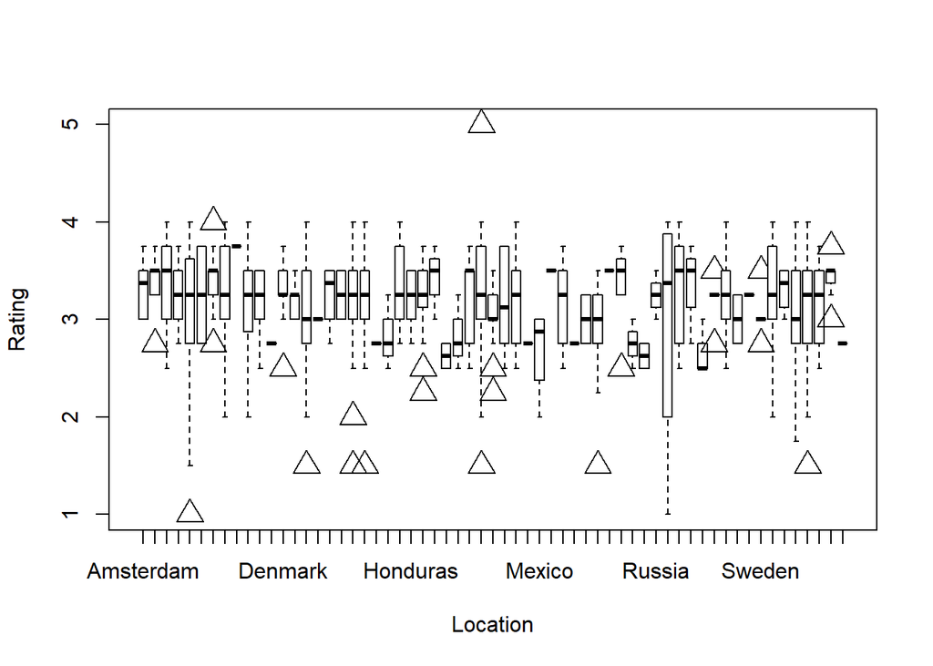

```r
plot(choco$Company.Location,choco$Rating, xlab = "Location", ylab = "Rating", pch = 2, cex=2)
```

The ratings are fairly similarly spread out among most companies, being around the 3-4 range, except for Russia which is very spread out through the 2-4 range.

5 . Brainstorm and write down an interesting question that can be answer from the dataset. The question should not duplicate the questions above.

Does the review date change the spread of ratings?

```r
sort(choco$Review.Date)
```

[output not shown]

[output cut: 128 more lines]

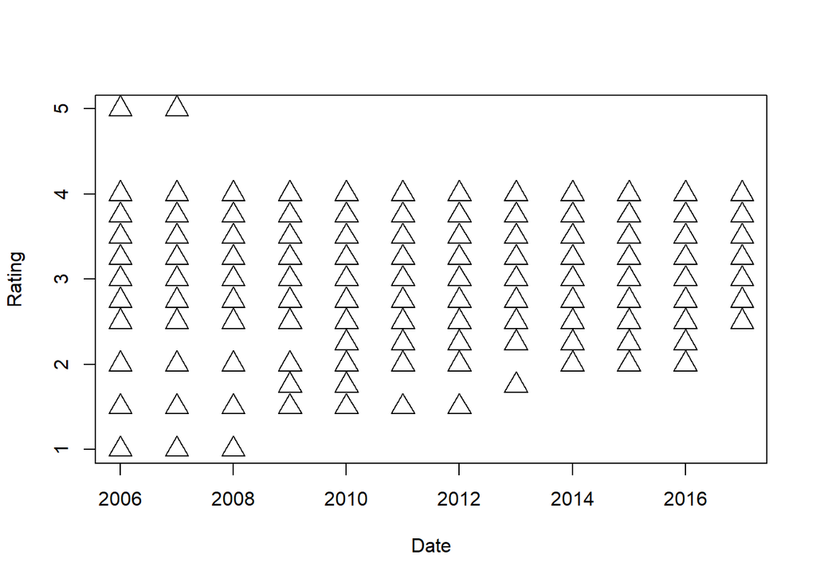

```r
plot(choco$Review.Date,choco$Rating, xlab = "Date", ylab = "Rating", pch = 2, cex=2)
```

More 5 star ratings were given in 2006 and 2007 than any other year. In recent years, the spread of ratings has decreased.